# 306.3. Host galaxy association for low-z supernovae

For the Rubin Science Platform at data.lsst.cloud.  
Data Release: [Data Preview 2](https://dp2.lsst.io/)  
Container Size: Large  
LSST Science Pipelines version: r30.0.11  
Last verified to run: 2026-11-21  
Repository: github.com/lsst/tutorial-notebooks  
DOI: 10.11578/rubin/dc.20250909.20

**Learning objective:** Understand the challenges in associating extragalactic, low-redshift time-domain objects like supernovae with potential host galaxies in DP2.

**LSST data products:** `DiaObject`, `Object`, `deep_coadd`

**Packages:** `lsst.rsp`

**Credit:** Originally developed by the Rubin Community Science team. Please consider acknowledging them if this notebook is used for the preparation of journal articles, software releases, or other notebooks.

**Get Support:** Everyone is encouraged to ask questions or raise issues in the [Support Category](https://community.lsst.org/c/support) of the Rubin Community Forum. Rubin staff will respond to all questions posted there.

## 1. Introduction

The identification of candidate host galaxies for an extragalactic transient is not straightforward.

**This tutorial is intended as a cautionary tale**, and demonstrates some of the challenges of associating low-redshift supernovae to potential host galaxies - especially the challenges particular to the nature of the Data Preview 2 (DP2) deep coadd images and `Object` table. True host identification typically requires spectroscopic confirmation. The identification of candidates ideally includes photometric redshift estimates and priors based on the transient and galaxy classifications, in addition to assessments of 2D sky separation as demonstrated in this tutorial.

**Challenges of low-redshift supernova host association with DP2.**

**Background interloping galaxies.**  
The issue of background interloper galaxies that are "nearby" in 2D distance along the line of sight, but not physically associated with the transient, is already challenging and will become more so as the LSST progresses to deeper limiting magnitudes.

**Deep coadd contamination.**  
The DP2 images were obtained between Apr 25 2025 and Jan 07 2026, but in some sky regions most of the images were obtained over a more constrained time frame. If that time frame happens to coincide with an extragalactic transient, the deep coadd images can be "contaminated" by its light, and the transient detected and reported in the `Object` table. This must be kept in mind and accounted for when identifying potential hosts in the `Object` table.

**Deblender shredding.**  
Large low-redshift galaxies with lots of internal substructure (spiral arms, clusters, bulge, and so on) can be "shredded" by the deblender. When parts of a galaxy are identified as separarate child objects in the `Object` table, the transient can be cross-matched to one of these children instead of the parent object (the galaxy). The measured galaxy size, Kron radius, and adaptive moments (luminosity profiles) are all impacted by deblender shredding.

**No pre-calculated host association parameters in DP2.**  
The DP2 `DiaObject` table **does not contain** the host association parameters described in the Rubin Observatory Data Products Definitions Document ([DPDD](https://docushare.lsstcorp.org/docushare/dsweb/Get/LSE-163/LSE-163_DataProductsDefinitionDocumentDPDD.pdf)) and in the Data Management Tech Note "Host Galaxy Association for DIAObjects" ([DMTN-151](https://dmtn-151.lsst.io/)). These future parameters are: (1) the three nearest point-like and extended Objects by 2D radial distance; (2) the three extended Objects with the lowest separations (using, e.g., second moments of the luminosity profile for effective elliptical separation); and (3) the distance to the nearest low-redshift galaxy from a separate catalog (e.g., NED). As there parameters are not included in the DP2 `DiaObject` table, this tutorial demonstrates how to use several of the galaxy shape parameters in the DP2 `Object` table to associate extragalactic transients with potential host galaxies.

In this notebook, three options for measuring the "separation" between transient coordinates and a potential host galaxy are demonstrated.

1. **2D sky distance:** The offset, in arcseconds or pixels, between the transient coordinates and a potential host galaxy's centroid.
2. **Effective Kron separation:** The Kron radius for a galaxy is based on the first moment of its light profile ([Kron 1980](https://ui.adsabs.harvard.edu/abs/1980ApJS...43..305K/abstract)). It is more typically used for flux measurements than for galaxy size and shape, as twice the Kron radius will capture >90% of the galaxy flux. In the `Object` table, the Kron radius for a given filter, e.g., `r_kronRad`, is the square root of the product of the semi-major and semi-minor axes of the galaxy, and it is given in units of pixels. The *effective* Kron separation is the distance bewteen the target and the galaxy barycenter, divided by the galaxy's Kron radius.
3. **Effective elliptical separation:** This is based on the adaptive second moments of the galaxy's luminosity profile. In the `Object` table, the second moments for the reference band are provided in the `shape_xx` ($Ixx$), `shape_yy` ($Iyy$), and `shape_xy` ($Ixy$) columns, in pixels. The same measures are also provided per-band, e.g., `i_ixx`, `i_iyy`, and `i_ixy`. Where $x$ and $y$ are RA and Declination, respectively, and $ \delta x = x_{SN}-x_{galaxy} $ and $ \delta y = y_{SN}-y_{galaxy} $ are also in pixels, the effective elliptical separation $R$ can be calculated with the equations below. See also [this description and graphic of the ellipse parameters CXX, CYY, CXY in the Source Extractor documentation by E. Bertin](https://sextractor.readthedocs.io/en/latest/Position.html#ellipse-parameters-cxx-cyy-cxy). $$ C_{xx} = {I_{yy} \over {I_{xx}I_{yy} - I_{xy}^2}} $$ $$ C_{yy} = {I_{xx} \over {I_{xx}I_{yy} - I_{xy}^2}} $$ $$ C_{xy} = {-2 I_{xy} \over {I_{xx}I_{yy} - I_{xy}^2}} $$ $$ R^2 = C_{xx}(\delta x)^2 + C_{yy}(\delta y)^2 + C_{xy}(\delta x)(\delta y) $$

**Related tutorials:** The other 300-level tutorials in this series on extragalactic transients, the 200-level tutorials on deep coadd images and the `Object` table, and the 100-level tutorials on accessing catalogs with the TAP service, and image access and display.

### 1.1. Import packages

Import standard python packages `numpy`, `matplotlib`, and `astropy`, along with modules from the LSST Science Pipelines for data access and display.

```python
import numpy as np
import matplotlib.pyplot as plt
import matplotlib.colors as mcolors
from astropy.coordinates import SkyCoord
from astropy.visualization import ZScaleInterval
from astropy.table import Table, join
import lsst.afw.display as afwDisplay
from lsst.rsp import RSPDiscovery
from lsst.daf.butler import Butler, EmptyQueryResultError
from lsst.images import Box
from lsst.utils.plotting import (get_multiband_plot_colors,
                                 get_multiband_plot_symbols,
                                 get_multiband_plot_linestyles)
```

### 1.2. Define parameters and functions

Instantiate the TAP service.

```python
discovery = RSPDiscovery("dp2")
tap_service = discovery.get_tap_client()
```

Instatiate the Butler.

```python
butler = Butler('dp2', collections="dp2")
```

Set the style for plots.

```python
filter_colors = get_multiband_plot_colors()
filter_symbols = get_multiband_plot_symbols()
filter_linestyles = get_multiband_plot_linestyles()
filter_names = filter_colors.keys()
```

Set `afwDisplay` to use `matplotlib`.

```python
afwDisplay.setDefaultBackend("matplotlib")
```

## 2. Supernovae in DP2

Tutorial 306.2 cross-matches supernovae from the Transient Name Server with the DP2 `DiaObject` catalog. Use the five of these with the highest number of detections in DP2 as a sample for this tutorial.

- [SN 2025mbp](https://www.wis-tns.org/object/2025mbp) - SN Ia at z=0.04616
- [SN 2026bbl](https://www.wis-tns.org/object/2026bbl) - SN II at z=0.1139
- [SN 2025hlf](https://www.wis-tns.org/object/2025hlf) - SN II at z=0.0732
- [SN 2025sfo](https://www.wis-tns.org/object/2025sfo) - SLSN-I at z=0.22
- [SN 2025imw](https://www.wis-tns.org/object/2025imw) - SN Ia at z=0.02

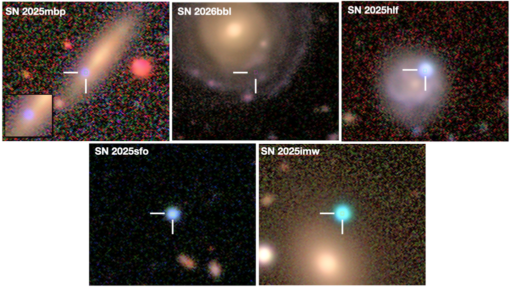

**Figure 1:** Cutouts of the DP2 HiPS $gri$ deep coadd color images ($\sim$40" per side) centered on five cross-matched TNS supernovae (marked with white lines). Blue-ish point-like sources at the locations of four of the five indicate the supernova light has contaminated the deep coadd image. For SN 2025mbp (upper left) the supernova light is is subtle, and the inset shows it best. Only for SN 2026bbl (upper middle) is there is no obvious supernova light in the $gri$ color image.

Known host galaxy information:

- SN 2025mbp - the large inclined galaxy in which the supernova is embedded is the confirmed host by redshift ([SN 2025mbp in WISeREP](https://www.wiserep.org/object/28251)).
- SN 2026bbl - the large face-on spiral galaxy in which the supernova is embedded is the confirmed host by redshift ([SN 2026bbl in WISeREP](https://www.wiserep.org/object/29977) and the [SDSS spectrum of the galaxy](https://skyserver.sdss.org/dr16/en/tools/explore/Summary.aspx?id=1237651754534306014)).
- SN 2025hlf - the large face-on spiral galaxy in which the supernova is embedded is the confirmed host by redshift ([SN 2025hlf in WISeREP](https://www.wiserep.org/object/28233) and the [SDSS spectrum of the galaxy](https://skyserver.sdss.org/dr16/en/tools/explore/Summary.aspx?id=1237658491208204508))
- SN 2025sfo - no confirmed host, but there appears to be a faint point-like source at the location in pre-SN images, see [SN 2025sfo in TNS](https://www.wis-tns.org/object/2025sfo).
- SN 2025imw - no confirmed host, and the by-eye likely host *seems* to be the large bright elliptical to the south of the supernova but... see also Section 5!

Define a table of the supernova names and `diaObjectId` values.

```python
sns = ['SN 2025mbp', 'SN 2026bbl', 'SN 2025hlf', 'SN 2025sfo', 'SN 2025imw']
ids = [786352299365629972, 788015379422118937, 794819432252702737,
       767356243130974229, 764124984615370762]
sn_table = Table([sns, ids], names=('sn_name', 'diaObjectId'))
```

Get the coordinates and number of detections from the `DiaObject` table.

```python
id_list = "(" + ", ".join(str(value) for value in sn_table['diaObjectId']) + ")"
query = """SELECT diaObjectId, ra, dec, nDiaSources
        FROM dp2.DiaObject WHERE diaObjectId IN {}""".format(id_list)
job = tap_service.submit_job(query)
job.run()
job.wait(phases=['COMPLETED', 'ERROR'])
print('Job phase is', job.phase)
if job.phase == 'ERROR':
    job.raise_if_error()
assert job.phase == 'COMPLETED'
dia_objects = job.fetch_result().to_table()
```

```
Job phase is COMPLETED
```

Join `sn_table` and `dia_objects` to create the `targets` table and sort by `nDiaSources`.

```python
targets = join(sn_table, dia_objects, keys='diaObjectId')
targets.sort('nDiaSources', reverse=True)
```

Display the table.

```python
targets
```

*Table length=5*

| sn_name str10 | diaObjectId int64 | ra deg float64 | dec deg float64 | nDiaSources int64 |
| --- | --- | --- | --- | --- |
| SN 2025mbp | 786352299365629972 | 151.59257896051943 | 1.1583327992593264 | 201 |
| SN 2026bbl | 788015379422118937 | 150.54933226436015 | 2.6268930121860863 | 184 |
| SN 2025hlf | 794819432252702737 | 185.9885437871332 | 8.76318574956208 | 147 |
| SN 2025sfo | 767356243130974229 | 320.0731253627078 | -17.208925262103698 | 74 |
| SN 2025imw | 764124984615370762 | 310.17861663711346 | -20.435673493712155 | 72 |

Retrieve the forced difference-image photometry (the lightcurves) from the `ForcedSourceOnDiaObject` table.

```python
query = """SELECT fsodo.diaObjectId, fsodo.psfDiffFlux,
        fsodo.psfDiffFluxErr, fsodo.band, v.expMidptMJD
        FROM dp2.ForcedSourceOnDiaObject AS fsodo
        JOIN dp2.Visit AS v ON v.visit = fsodo.visit
        WHERE fsodo.diaObjectId IN {}""".format(id_list)
job = tap_service.submit_job(query)
job.run()
job.wait(phases=['COMPLETED', 'ERROR'])
print('Job phase is', job.phase)
if job.phase == 'ERROR':
    job.raise_if_error()
assert job.phase == 'COMPLETED'
flux_table = job.fetch_result().to_table()
```

```
Job phase is COMPLETED
```

Option to display the table.

```python
# flux_table
```

Display the forced difference-image flux lightcurves. Recall that, because the template coadd images can also be contaminated by supernova flux, difference-image fluxes can be $<$0 when the supernova is brighter in the template coadd than in the visit image. Include a horizontal line at flux = 0 to guide the eye.

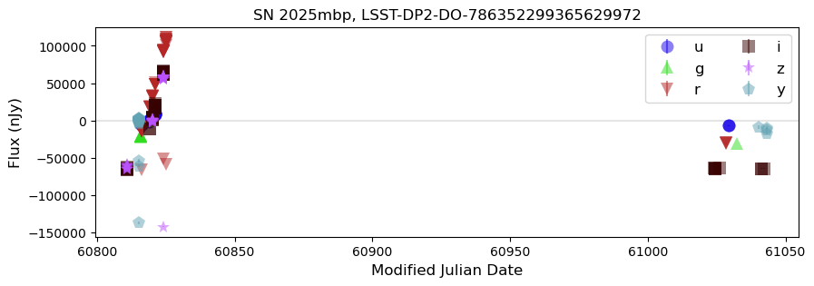

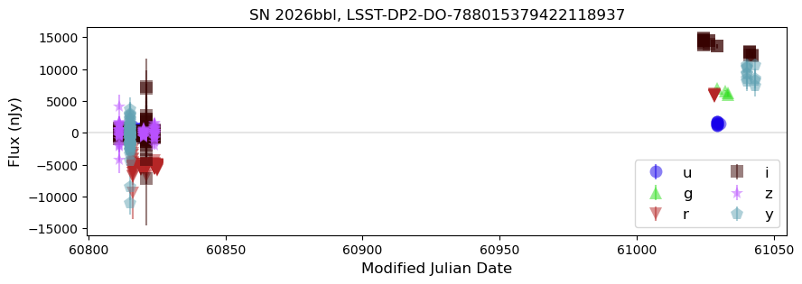

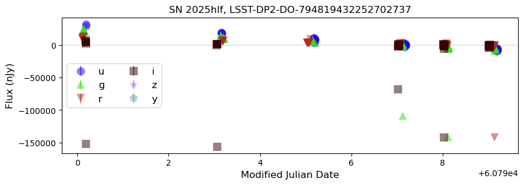

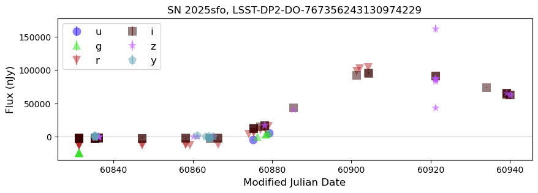

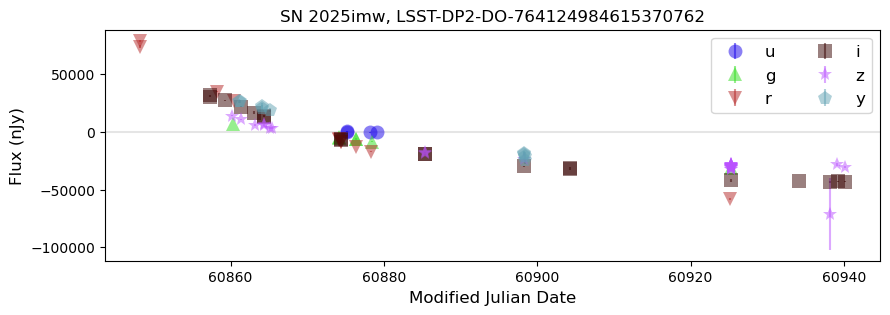

```python
for i in range(len(targets)):
    fig = plt.figure(figsize=(10, 3))
    plt.axhline(0, alpha=0.2, color='grey')
    for f, filt in enumerate(filter_names):
        fx = np.where((flux_table['diaObjectId'] == targets['diaObjectId'][i])
                      & (flux_table['band'] == filt))[0]
        plt.errorbar(flux_table['expMidptMJD'][fx], flux_table['psfDiffFlux'][fx],
                     yerr=flux_table['psfDiffFluxErr'][fx], fmt=filter_symbols[filt],
                     ms=10, mew=0, alpha=0.5, color=filter_colors[filt], label=filt)
    plt.xlabel('Modified Julian Date', fontsize=12)
    plt.ylabel('Flux (nJy)', fontsize=12)
    plt.legend(loc='best', ncol=2, fontsize=12)
    plt.title(targets['sn_name'][i] + ", LSST-DP2-DO-" + str(targets['diaObjectId'][i]))
    plt.show()
```

> **Figure 2:** The forced difference-image flux vs. modified Julian date for the 5 targeted supernovae. This plot shows the diversity in their lightcurves. The fact that some extend to negative difference-image flux indicates that the template coadd image contained light from the supernova itself.

## 3. Check for deep coadd contamination

**Checking a deep coadd image for supernova flux contamination is not a typical step of the host association process.** However, due to the deep coadd contamination issue for DP2 as described in the introduction, a visual check of the deep coadd images (Section 3.1) and a cross-match between the deep coadd input visit dates and the dates when the supernova was bright (Section 3.2) are a useful demonstration.

### 3.1. Display the deep coadd images

Display the deep coadd images in each filter $ugrizy$ in order to explore by eye any contamination by supernova light.

For each target, create a grid plot of deep coadd image cutouts centered on the supernova's coordinates.

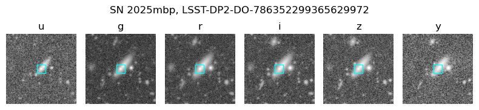

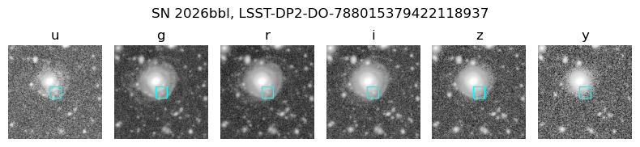

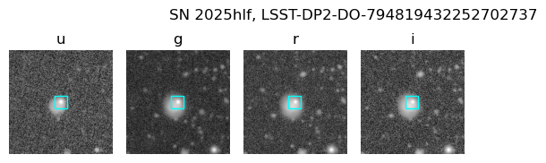

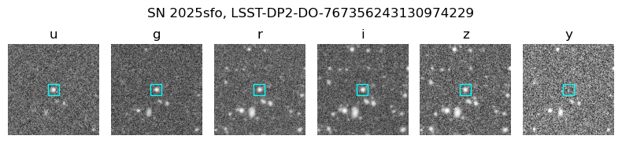

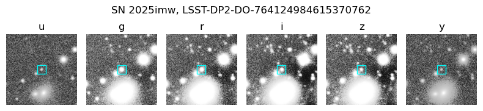

```python
subset_size = 150
for i in range(len(targets)):
    query = """band.name = :band AND patch.region OVERLAPS POINT(:ra, :dec)"""
    binder = {"band": 'i', "ra": targets['ra'][i], "dec": targets['dec'][i]}
    refs = butler.query_datasets("deep_coadd", where=query, bind=binder)
    data_id = refs[0].dataId
    use_tract = data_id['tract']
    use_patch = data_id['patch']
    wcs = butler.get("deep_coadd.sky_projection", dataId=data_id)
    sn_coord = SkyCoord(targets['ra'][i], targets['dec'][i], unit="deg")
    sn_xy = wcs.sky_to_pixel(sn_coord)
    selection_bbox = Box.factory[round(sn_xy.y):round(sn_xy.y)+1,
                                 round(sn_xy.x):round(sn_xy.x)+1].padded(subset_size)
    params = {'bbox': selection_bbox}

    cutouts = []
    cutout_ok = []
    for filt in ['u', 'g', 'r', 'i', 'z', 'y']:
        try:
            query = """band.name = '{}' AND tract.id = {}
                    AND patch IN ({})""".format(filt, use_tract, use_patch)
            refs = butler.query_datasets("deep_coadd", where=query)
            subset = butler.get(refs[0], parameters=params)
            cutouts.append(subset)
            cutout_ok.append(True)
            del subset
        except EmptyQueryResultError:
            cutouts.append([])
            cutout_ok.append(False)

    fig, axes = plt.subplots(nrows=1, ncols=6, figsize=(8, 3))
    axes = axes.flatten()
    for f, filt in enumerate(['u', 'g', 'r', 'i', 'z', 'y']):
        if cutout_ok[f]:
            img_array = cutouts[f].image.array
            cutout_extent = (cutouts[f].bbox.x.start, cutouts[f].bbox.x.stop,
                             cutouts[f].bbox.y.start, cutouts[f].bbox.y.stop)
            zscale = ZScaleInterval(krej=1)
            vmin, vmax = zscale.get_limits(img_array)
            norm = mcolors.AsinhNorm(linear_width=1.0, vmin=vmin, vmax=vmax)
            axes[f].imshow(img_array, cmap='gray', norm=norm, extent=cutout_extent, origin='lower')
            axes[f].set_title(filt)
            axes[f].axis("off")
            axes[f].plot(sn_xy.x, sn_xy.y, 's', ms=10, mew=1, color='None', mec='cyan')
            del img_array
        else:
            axes[f] = axes[f]
            axes[f].remove()
    plt.suptitle(targets['sn_name'][i] + ", LSST-DP2-DO-" + str(targets['diaObjectId'][i]), y=0.8)
    plt.tight_layout()
    plt.show()

    del cutouts
```

### 3.2. Review the deep coadd input dates

Display again the supernova lightcurves, but mark which epochs contributed to the deep coadd image. If the deep coadd image was built mostly from visits that were obtained while a supernova was bright, it is more likely that the deep coadd image will be contaminated with supernova flux.

Retrieve the $i$-band deep coadd image in order to use its grid index to figure out which cell the supernova's location falls in. For a refresher on the cell-based nature of deep coadd images, see the [What's new with DP2 images](https://dp2.lsst.io/products/images/new_lsst_image_format.html) webpage or the 200-level tutorial on deep coadd images. Collect all the input visits for each target in one table.

```python
temp0 = []
temp1 = []
temp2 = []
for i in range(len(targets)):
    query = """band.name = :band AND patch.region OVERLAPS POINT(:ra, :dec)"""
    binder = {"band": 'i', "ra": targets['ra'][i], "dec": targets['dec'][i]}
    refs = butler.query_datasets("deep_coadd", where=query, bind=binder)
    data_id = refs[0].dataId
    use_tract = data_id['tract']
    use_patch = data_id['patch']
    deep_coadd = butler.get("deep_coadd", dataId=data_id)
    wcs = deep_coadd.sky_projection
    sn_coord = SkyCoord(targets['ra'][i], targets['dec'][i], unit="deg")
    sn_xy = wcs.sky_to_pixel(sn_coord)
    cij = deep_coadd.grid.index_of(x=sn_xy.x, y=sn_xy.y)
    del deep_coadd

    for filt in ['u', 'g', 'r', 'i', 'z', 'y']:
        try:
            query = """band.name = '{}' AND tract.id = {}
                    AND patch IN ({})""".format(filt, use_tract, use_patch)
            refs = butler.query_datasets("deep_coadd", where=query)
            data_id = refs[0].dataId
            provenance = butler.get("deep_coadd.provenance", dataId=data_id)
            contributions = provenance.contributions
            tx = np.where((contributions['cell_i'] == cij.i)
                          & (contributions['cell_j'] == cij.j))[0]
            for x in tx:
                temp0.append(targets['diaObjectId'][i])
                temp1.append(int(contributions['visit'][x]))
                temp2.append(filt)
        except EmptyQueryResultError:
            pass
inputs = Table([temp0, temp1, temp2], names=['diaObjectId', 'visit', 'band'])
del temp0, temp1, temp2
```

Retrieve the date of all the collected visits from the `Visit` table.

```python
visit_list = "(" + ", ".join(str(value) for value in inputs['visit']) + ")"
query = """SELECT visit, expMidptMJD
        FROM dp2.Visit WHERE visit IN {}""".format(visit_list)
job = tap_service.submit_job(query)
job.run()
job.wait(phases=['COMPLETED', 'ERROR'])
print('Job phase is', job.phase)
if job.phase == 'ERROR':
    job.raise_if_error()
visits = job.fetch_result().to_table()
```

```
Job phase is COMPLETED
```

Join the tables of inputs and visit dates.

```python
input_visits = join(inputs, visits, keys='visit')
```

Option to display the input visits table.

```python
# input_visits
```

Display the supernova lightcurve as in Figure 2, and mark dates that were used as input visits to the deep coadd image with vertical gray lines.

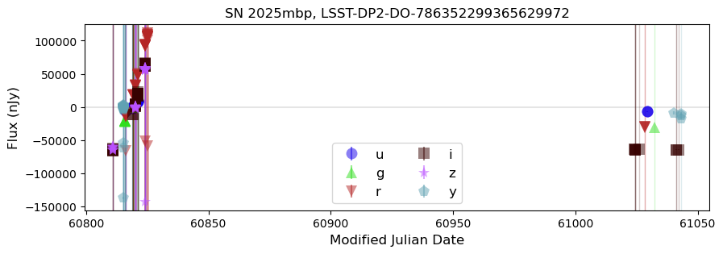

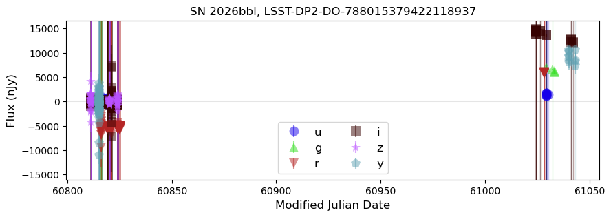

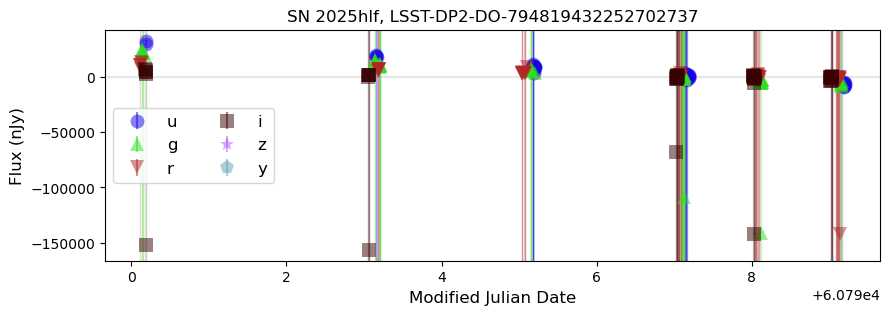

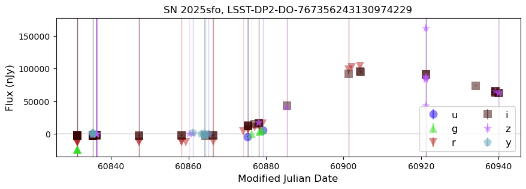

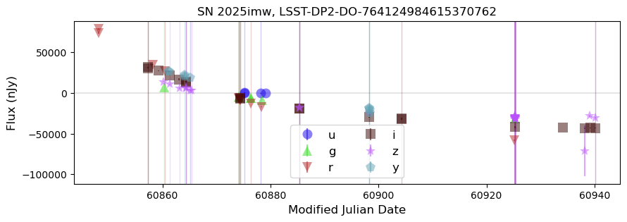

```python
for i in range(len(targets)):
    fig = plt.figure(figsize=(10, 3))
    plt.axhline(0, alpha=0.2, color='grey')
    for f, filt in enumerate(filter_names):
        fx = np.where((input_visits['diaObjectId'] == targets['diaObjectId'][i])
                      & (input_visits['band'] == filt))[0]
        if len(fx) > 0:
            for x in fx:
                plt.axvline(input_visits['expMidptMJD'][x], lw=1,
                            alpha=0.2, color=filter_colors[filt])
    for f, filt in enumerate(filter_names):
        fx = np.where((flux_table['diaObjectId'] == targets['diaObjectId'][i])
                      & (flux_table['band'] == filt))[0]
        plt.errorbar(flux_table['expMidptMJD'][fx], flux_table['psfDiffFlux'][fx],
                     yerr=flux_table['psfDiffFluxErr'][fx], fmt=filter_symbols[filt],
                     ms=10, mew=0, alpha=0.5, color=filter_colors[filt], label=filt)
    plt.xlabel('Modified Julian Date', fontsize=12)
    plt.ylabel('Flux (nJy)', fontsize=12)
    plt.legend(loc='best', ncol=2, fontsize=12)
    plt.title(targets['sn_name'][i] + ", LSST-DP2-DO-" + str(targets['diaObjectId'][i]))
    plt.show()
```

> **Figure 4:** Each supernova's lightcurve with vertical lines marking visits that contributed to the deep coadd image. The filters for which the input visits included dates where the supernova was bright are more likely to exhibit supernova light in their deep coadd image in Figure 3.

## 4. Cross-match to the Object table

Cross-matching the supernovae to the `Object` table is the typical first step in host association.

Query the `Object` table using a 30 arcsecond radius around each target (**see Section 5 for a demonstration of how this can be too small for low-redshift transients**). Retreive the $i$-band photometry, Kron radius, and adaptive moments, and the extendedness parameters in the reference band for each object. Require that the $i$-band flux have a signal-to-noise ratio greater than 5.

> **Notice:** This query typically takes a few minutes to execute.

```python
rad_deg = 30.0/3600.0
query = """SELECT ut.sn_name, ut.diaObjectId, ut.ra, ut.dec, ut.nDiaSources,
        o.objectId, o.coord_ra, o.coord_dec, o.refBand, o.refExtendedness,
        o.refSizeExtendedness, o.i_psfFlux, o.i_psfFluxErr, o.i_psfFlux_flag,
        o.i_cModelFlux, o.i_cModelFluxErr, o.i_cModel_flag, o.i_kronRad,
        o.i_kronFlux_flag, o.i_kronFlux_flag_bad_radius, o.i_ixx, o.i_ixy, o.i_iyy,
        DISTANCE(POINT('ICRS', o.coord_ra, o.coord_dec),
        POINT('ICRS', ut.ra, ut.dec))*3600 AS distance_arcsec
        FROM dp2.Object AS o
        JOIN TAP_UPLOAD.ut AS ut
        ON DISTANCE(POINT('ICRS', o.coord_ra, o.coord_dec),
                    POINT('ICRS', ut.ra, ut.dec)) < {}
        WHERE o.i_psfFlux/o.i_psfFluxErr > 5 OR o.i_cModelFlux/o.i_cModelFluxErr > 5
        """.format(rad_deg)
job = tap_service.submit_job(query, uploads={"ut": targets})
job.run()
job.wait(phases=['COMPLETED', 'ERROR'])
print('Job phase is', job.phase)
if job.phase == 'ERROR':
    job.raise_if_error()
assert job.phase == 'COMPLETED'
objects = job.fetch_result().to_table()
```

```
Job phase is COMPLETED
```

Option to display the table.

```python
# objects
```

For each target, retrieve the $i$-band deep coadd cutout image.

```python
cutouts = []
for i in range(len(targets)):
    query = """band.name = :band AND patch.region OVERLAPS POINT(:ra, :dec)"""
    binder = {"band": 'i', "ra": targets['ra'][i], "dec": targets['dec'][i]}
    refs = butler.query_datasets("deep_coadd", where=query, bind=binder)
    data_id = refs[0].dataId
    use_tract = data_id['tract']
    use_patch = data_id['patch']
    wcs = butler.get("deep_coadd.sky_projection", dataId=data_id)
    sn_coord = SkyCoord(targets['ra'][i], targets['dec'][i], unit="deg")
    sn_xy = wcs.sky_to_pixel(sn_coord)
    subset_size = 150
    selection_bbox = Box.factory[round(sn_xy.y):round(sn_xy.y)+1,
                                 round(sn_xy.x):round(sn_xy.x)+1].padded(subset_size)
    params = {'bbox': selection_bbox}
    query = """band.name = 'i' AND tract.id = {}
            AND patch IN ({})""".format(use_tract, use_patch)
    refs = butler.query_datasets("deep_coadd", where=query)
    subset = butler.get(refs[0], parameters=params)
    cutouts.append(subset)
    del subset
```

Display the $i$-band deep coadd cutout images and mark objects.

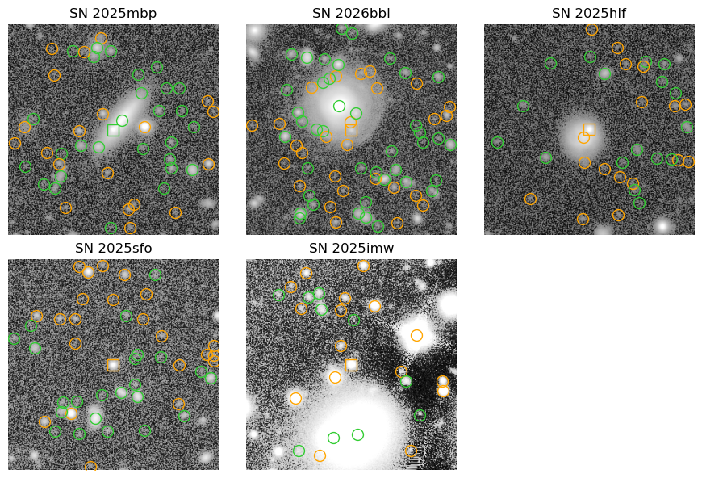

```python
fig, axes = plt.subplots(nrows=2, ncols=3, figsize=(9, 6))
axes = axes.flatten()
for i in range(len(targets)):
    subset = cutouts[i]
    wcs = subset.sky_projection
    subset_extent = (subset.bbox.x.start, subset.bbox.x.stop,
                     subset.bbox.y.start, subset.bbox.y.stop)
    img_array = subset.image.array
    zscale = ZScaleInterval(krej=1)
    vmin, vmax = zscale.get_limits(img_array)
    norm = mcolors.AsinhNorm(linear_width=1.0, vmin=vmin, vmax=vmax)
    axes[i].imshow(img_array, cmap='gray', norm=norm, extent=subset_extent, origin='lower')
    tx = np.where(objects['diaObjectId'] == targets['diaObjectId'][i])[0]
    for x in tx:
        color = 'limegreen'
        symbol = 'o'
        if (objects['refExtendedness'][x] == 0) or \
           (objects['refSizeExtendedness'][x] < 0.5) or \
           (objects['refExtendedness'].mask[x]):
            color = 'orange'
        if objects['distance_arcsec'][x] < 0.5:
            symbol = 's'
        coord = SkyCoord(objects['coord_ra'][x], objects['coord_dec'][x], unit="deg")
        xy = wcs.sky_to_pixel(coord)
        axes[i].plot(xy.x, xy.y, symbol, ms=10, color='None', mec=color, mew=1)
    axes[i].set_title(targets['sn_name'][i])
    axes[i].axis("off")
    del subset
axes[5].remove()
plt.tight_layout()
plt.show()
```

> **Figure 5:** The $i$-band deep coadd cutout images, centered on the supernova's coordinates, with nearby objects marked. The default marker type is a green circle, but the marker will be a square for any object within 0.5 arcseconds (potentially the supernova itself), or orange if the object **was not** identified as likely to be extended (and thus less likely to be a host galaxy for the low-redshift supernova).

### 4.1. Is the transient in the Object table

Check if there is an object within 0.5 arcseconds of the supernova's coordinates from the `DiaObject` table.

*In general*, finding a very close object does not necessarily mean that it is the transient. Especially at higher redshifts, host galaxies can be point-like and angular separations between transient and host can be very low. This may be the case for $z=0.22$ SN 2025sfo, especially since Figure 4 shows that relatively fewer deep coadd inputs came from the time when that supernova was bright. However, for the other four low-redshift supernovae in DP2, given what was demonstrated about input visits contributing to the deep coadd image, it is more likely that in it is the transient in the object table.

Print the objects within 0.5 of each supernova.

```python
tx = np.where(objects['distance_arcsec'] < 0.5)[0]
objects[tx]
```

*Table length=5*

| sn_name str10 | diaObjectId int64 | ra deg float64 | dec deg float64 | nDiaSources int64 | objectId int64 | coord_ra deg float64 | coord_dec deg float64 | refBand str1 | refExtendedness float32 | refSizeExtendedness float32 | i_psfFlux nJy float32 | i_psfFluxErr nJy float32 | i_psfFlux_flag bool | i_cModelFlux nJy float32 | i_cModelFluxErr nJy float32 | i_cModel_flag bool | i_kronRad pix float32 | i_kronFlux_flag bool | i_kronFlux_flag_bad_radius bool | i_ixx pix2 float32 | i_ixy pix2 float32 | i_iyy pix2 float32 | distance_arcsec float64 |
| --- | --- | --- | --- | --- | --- | --- | --- | --- | --- | --- | --- | --- | --- | --- | --- | --- | --- | --- | --- | --- | --- | --- | --- |
| SN 2025hlf | 794819432252702737 | 185.9885437871332 | 8.76318574956208 | 147 | 794819432252726614 | 185.98852502138436 | 8.763208548300305 | i | 1.0 | 0.144987 | 139400.0 | 78.6427 | False | 147512.0 | 82.8196 | False | 4.24187 | False | False | 7.08582 | -0.112006 | 7.53902 | 0.10580338268479292 |
| SN 2025mbp | 786352299365629972 | 151.59257896051943 | 1.1583327992593264 | 201 | 786352299365657276 | 151.59255089414864 | 1.1583221009904412 | i | 1.0 | 1.0 | 81619.3 | 66.2424 | False | 277259.0 | 186.448 | False | 10.2374 | False | False | 16.6249 | 7.3573 | 19.0053 | 0.10811107602628751 |
| SN 2026bbl | 788015379422118937 | 150.54933226436015 | 2.6268930121860863 | 184 | 788015379422144379 | 150.54935179665918 | 2.6269179302149057 | i | -- | -- | 3648.2 | 25.6689 | True | 15834.2 | 94.668 | False | 5.87791 | True | False | 19.7144 | -5.17885 | 19.106 | 0.11393402668394335 |
| SN 2025imw | 764124984615370762 | 310.17861663711346 | -20.435673493712155 | 72 | 764124984615391585 | 310.1786111267264 | -20.435673831290345 | i | 0.0 | 0.121695 | 49269.6 | 111.473 | False | 49427.9 | 112.501 | False | 3.50716 | False | False | 4.65524 | 0.0175328 | 4.92519 | 0.018628605769509466 |
| SN 2025sfo | 767356243130974229 | 320.0731253627078 | -17.208925262103698 | 74 | 767356243130995820 | 320.07312481042004 | -17.208919635684573 | i | 1.0 | 0.0121469 | 18848.6 | 66.4275 | False | 19183.2 | 67.9518 | False | 3.97593 | False | False | 6.51989 | 0.195478 | 5.90062 | 0.02034395483503666 |

### 4.2. Nearest objects

Option to print the three nearest objects by 2D distance (angular offset) for each of the supernovae.

```python
# cols = ['sn_name', 'objectId', 'distance_arcsec', 'i_cModelFlux']
# for i in range(len(targets)):
#     print('')
#     tx = np.where((objects['diaObjectId'] == targets['diaObjectId'][i])
#                   & (objects['distance_arcsec'] > 0.5))[0]
#     temp = objects[tx]
#     temp.sort('distance_arcsec')
#     print(temp[cols][0:3])
```

Mark the three nearest objects by 2D distance on the $i$-band cutout for each target.

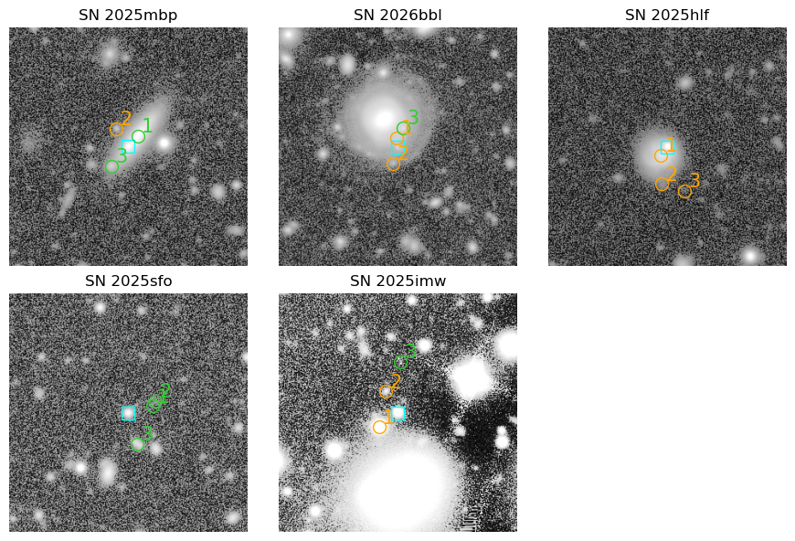

```python
fig, axes = plt.subplots(nrows=2, ncols=3, figsize=(9, 6))
axes = axes.flatten()
for i in range(len(targets)):
    subset = cutouts[i]
    wcs = subset.sky_projection
    subset_extent = (subset.bbox.x.start, subset.bbox.x.stop,
                     subset.bbox.y.start, subset.bbox.y.stop)
    img_array = subset.image.array
    zscale = ZScaleInterval(krej=1)
    vmin, vmax = zscale.get_limits(img_array)
    norm = mcolors.AsinhNorm(linear_width=1.0, vmin=vmin, vmax=vmax)
    axes[i].imshow(img_array, cmap='gray', norm=norm, extent=subset_extent, origin='lower')
    sn_coord = SkyCoord(targets['ra'][i], targets['dec'][i], unit="deg")
    sn_xy = wcs.sky_to_pixel(sn_coord)
    axes[i].plot(sn_xy.x, sn_xy.y, 's', ms=10, color='None', mec='cyan', mew=1)
    tx = np.where((objects['diaObjectId'] == targets['diaObjectId'][i])
                  & (objects['distance_arcsec'] > 0.5))[0]
    temp = objects[tx]
    temp.sort('distance_arcsec')
    for x in range(3):
        color = 'limegreen'
        symbol = 'o'
        if (temp['refExtendedness'][x] == 0) or \
           (temp['refSizeExtendedness'][x] < 0.5) or \
           (temp['refExtendedness'].mask[x]):
            color = 'orange'
        coord = SkyCoord(temp['coord_ra'][x], temp['coord_dec'][x], unit="deg")
        xy = wcs.sky_to_pixel(coord)
        axes[i].plot(xy.x, xy.y, symbol, ms=10, color='None', mec=color, mew=1)
        axes[i].text(xy.x + 5, xy.y + 5, str(x+1), fontsize=15, color=color)
    axes[i].set_title(targets['sn_name'][i])
    axes[i].axis("off")
    del subset
axes[5].remove()
plt.tight_layout()
plt.show()
```

> **Figure 6:** Similar to Figure 5, but only the supernova's coordinates (cyan square) and the three nearest objects by 2D distance (angular offset) are marked with green circles, or orange circles if the object **was not** identified as likely to be extended (and thus less likely to be a host galaxy for the low-redshift SN).

Based on nearest objects by 2D sky distance:

- SN 2025mbp - the nearest extended object (green 1) is the confirmed host.
- SN 2026bbl - none of the three nearest objects are the confirmed host.
- SN 2025hlf - the nearest object (orange 1) is the confirmed host, but its parameters do not indicate its extendedness.
- SN 2025sfo - the situation is unclear.
- SN 2025imw - none of the three nearest objects are the potential large elliptical host.

### 4.3. Nearest extended objects

Option to print the three nearest *extended* objects by 2D distance (angular offset) for each of the supernovae.

```python
# cols = ['sn_name', 'objectId', 'distance_arcsec', 'i_cModelFlux',
#         'refExtendedness', 'refSizeExtendedness']
# for i in range(len(targets)):
#     print('')
#     tx = np.where((objects['diaObjectId'] == targets['diaObjectId'][i])
#                   & (objects['distance_arcsec'] > 0.5)
#                   & ((objects['refExtendedness'] == 1)
#                      | (objects['refSizeExtendedness'] >= 0.5)))[0]
#     temp = objects[tx]
#     temp.sort('distance_arcsec')
#     print(temp[cols][0:3])
```

Mark the three nearest extended objects by 2D distance on the $i$-band cutout for each supernova.

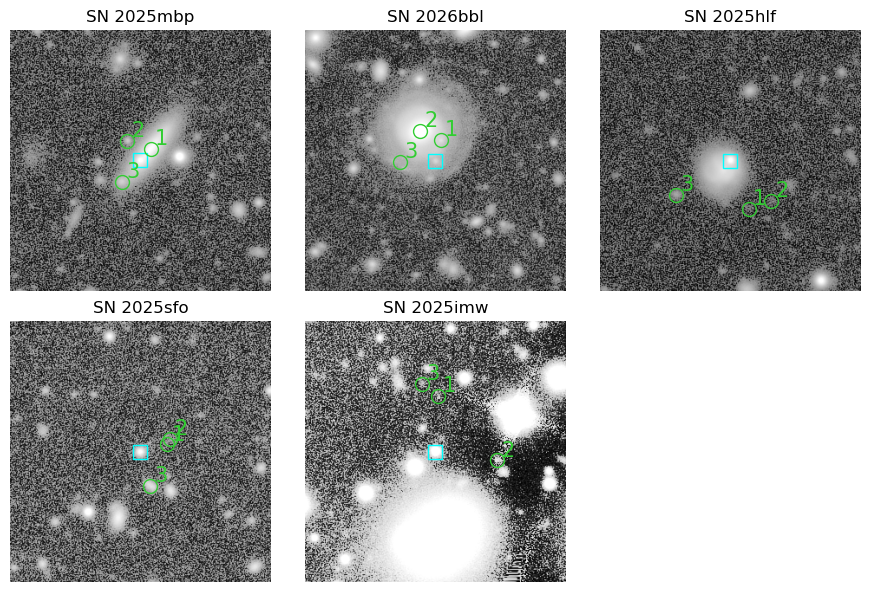

```python
fig, axes = plt.subplots(nrows=2, ncols=3, figsize=(9, 6))
axes = axes.flatten()
for i in range(len(targets)):
    subset = cutouts[i]
    wcs = subset.sky_projection
    subset_extent = (subset.bbox.x.start, subset.bbox.x.stop,
                     subset.bbox.y.start, subset.bbox.y.stop)
    img_array = subset.image.array
    zscale = ZScaleInterval(krej=1)
    vmin, vmax = zscale.get_limits(img_array)
    norm = mcolors.AsinhNorm(linear_width=1.0, vmin=vmin, vmax=vmax)
    axes[i].imshow(img_array, cmap='gray', norm=norm, extent=subset_extent, origin='lower')
    sn_coord = SkyCoord(targets['ra'][i], targets['dec'][i], unit="deg")
    sn_xy = wcs.sky_to_pixel(sn_coord)
    axes[i].plot(sn_xy.x, sn_xy.y, 's', ms=10, color='None', mec='cyan', mew=1)
    tx = np.where((objects['diaObjectId'] == targets['diaObjectId'][i])
                  & (objects['distance_arcsec'] > 0.5)
                  & ((objects['refExtendedness'] == 1)
                     | (objects['refSizeExtendedness'] >= 0.5)))[0]
    temp = objects[tx]
    temp.sort('distance_arcsec')
    for x in range(3):
        coord = SkyCoord(temp['coord_ra'][x], temp['coord_dec'][x], unit="deg")
        xy = wcs.sky_to_pixel(coord)
        axes[i].plot(xy.x, xy.y, symbol, ms=10, color='None', mec='limegreen', mew=1)
        axes[i].text(xy.x + 5, xy.y + 5, str(x+1), fontsize=15, color='limegreen')
    axes[i].set_title(targets['sn_name'][i])
    axes[i].axis("off")
    del subset
axes[5].remove()
plt.tight_layout()
plt.show()
```

> **Figure 7:** Similar to Figures 5 and 6, but only the supernova's coordinates (cyan square) and the three nearest *likely extended* objects by 2D distance (angular offset) are marked with green circles.

Based on nearest *extended* objects by 2D sky distance:

- SN 2025mbp - the nearest extended object is the confirmed host.
- SN 2026bbl - the second-nearest extended object is the confirmed host.
- SN 2025hlf - none of the nearest extended objects are the confirmed host (its parameters did not indicate its extendedness).
- SN 2025sfo - the situation is unclear.
- SN 2025imw - none of the three nearest extended objects are the potential large elliptical host.

### 4.4. Nearest extended objects by Kron radius

Calculate the *effective* Kron separation, which was introduced and described in Section 1.

```python
objects['distance_pix'] = objects['distance_arcsec'] / 0.2
objects['eff_kron_sep'] = objects['distance_pix'] / objects['i_kronRad']
```

Option to print the three nearest extended objects, by the measure of `eff_kron_sep`, that also have an unflagged Kron radius.

```python
# cols = ['sn_name', 'distance_arcsec', 'i_cModelFlux', 'i_kronRad', 'eff_kron_sep']
# for i in range(len(targets)):
#     print('')
#     tx = np.where((objects['diaObjectId'] == targets['diaObjectId'][i])
#                   & (objects['distance_arcsec'] > 0.5)
#                   & (objects['i_kronFlux_flag'] == 0)
#                   & (objects['i_kronFlux_flag_bad_radius'] == 0)
#                   & ((objects['refExtendedness'] == 1)
#                      | (objects['refSizeExtendedness'] >= 0.5)))[0]
#     temp = objects[tx]
#     temp.sort('eff_kron_sep')
#     print(temp[cols][0:3])
```

Mark the three nearest extended objects by effective Kron separation on the $i$-band cutout for each supernova.

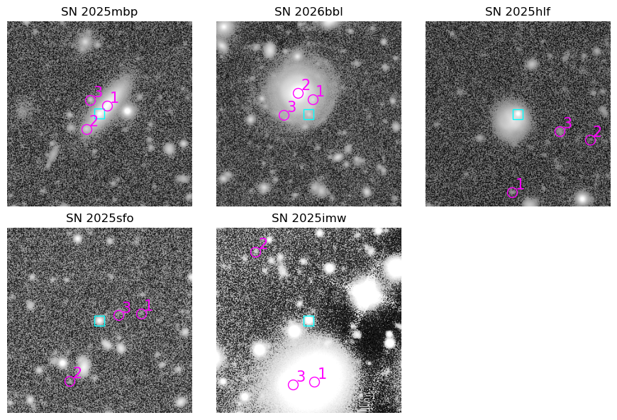

```python
fig, axes = plt.subplots(nrows=2, ncols=3, figsize=(9, 6))
axes = axes.flatten()
for i in range(len(targets)):
    subset = cutouts[i]
    wcs = subset.sky_projection
    subset_extent = (subset.bbox.x.start, subset.bbox.x.stop,
                     subset.bbox.y.start, subset.bbox.y.stop)
    img_array = subset.image.array
    zscale = ZScaleInterval(krej=1)
    vmin, vmax = zscale.get_limits(img_array)
    norm = mcolors.AsinhNorm(linear_width=1.0, vmin=vmin, vmax=vmax)
    axes[i].imshow(img_array, cmap='gray', norm=norm, extent=subset_extent, origin='lower')
    sn_coord = SkyCoord(targets['ra'][i], targets['dec'][i], unit="deg")
    sn_xy = wcs.sky_to_pixel(sn_coord)
    axes[i].plot(sn_xy.x, sn_xy.y, 's', ms=10, color='None', mec='cyan', mew=1)
    tx = np.where((objects['diaObjectId'] == targets['diaObjectId'][i])
                  & (objects['distance_arcsec'] > 0.5)
                  & (objects['i_kronFlux_flag_bad_radius'] == 0)
                  & ((objects['refExtendedness'] == 1)
                     | (objects['refSizeExtendedness'] >= 0.5)))[0]
    temp = objects[tx]
    temp.sort('eff_kron_sep')
    for x in range(3):
        coord = SkyCoord(temp['coord_ra'][x], temp['coord_dec'][x], unit="deg")
        xy = wcs.sky_to_pixel(coord)
        axes[i].plot(xy.x, xy.y, symbol, ms=10, color='None', mec='magenta', mew=1)
        axes[i].text(xy.x + 5, xy.y + 5, str(x+1), fontsize=15, color='magenta')
    axes[i].set_title(targets['sn_name'][i])
    axes[i].axis("off")
    del subset
axes[5].remove()
plt.tight_layout()
plt.show()
```

> **Figure 8:** Similar to Figures 5, 6, and 7, but only the supernova's coordinates (cyan square) and the three nearest likely extended objects by effective Kron separation are marked with magenta circles.

Based on nearest extended objects by Kron radius:

- SN 2025mbp - the nearest extended object is the confirmed host.
- SN 2026bbl - the second-nearest extended object is the confirmed host.
- SN 2025hlf - none of the nearest extended objects are the confirmed host.
- SN 2025sfo - the situation is unclear.
- SN 2025imw - the nearest extended object is the *potential* large elliptical host (but see Section 5).

### 4.5. Nearest objects by adaptive moments

Calculate the effective elliptical radius based on second moments, which was introduced and described in Section 1.

```python
objects['x'] = np.zeros(len(objects), dtype='float')
objects['y'] = np.zeros(len(objects), dtype='float')
objects['ell_r'] = np.zeros(len(objects), dtype='float')
for i in range(len(targets)):
    subset = cutouts[i]
    wcs = subset.sky_projection
    tx = np.where(objects['diaObjectId'] == targets['diaObjectId'][i])[0]
    coords = SkyCoord(objects['coord_ra'][tx], objects['coord_dec'][tx], unit="deg")
    xy = wcs.sky_to_pixel(coords)
    objects['x'][tx] = xy.x
    objects['y'][tx] = xy.y
    sn_coord = SkyCoord(targets['ra'][i], targets['dec'][i], unit="deg")
    sn_xy = wcs.sky_to_pixel(sn_coord)
    sn_x = sn_xy.x
    sn_y = sn_xy.y
    xr = sn_x - objects['x'][tx]
    yr = sn_y - objects['y'][tx]
    Cxx = objects['i_iyy'][tx] / ((objects['i_ixx'][tx] * objects['i_iyy'][tx])
                                  - objects['i_ixy'][tx])
    Cyy = objects['i_ixx'][tx] / ((objects['i_ixx'][tx] * objects['i_iyy'][tx])
                                  - objects['i_ixy'][tx])
    Cxy = -2.0 * (objects['i_ixy'][tx]) / ((objects['i_ixx'][tx] * objects['i_iyy'][tx])
                                           - objects['i_ixy'][tx])
    objects['ell_r'][tx] = np.sqrt((Cxx * xr**2) + (Cyy * yr**2) + (Cxy * xr * yr))
```

Option to print the three nearest extended objects, by the measure of `ell_r`.

```python
# cols = ['sn_name', 'distance_arcsec', 'i_cModelFlux', 'ell_r']
# for i in range(len(targets)):
#     print('')
#     tx = np.where((objects['diaObjectId'] == targets['diaObjectId'][i])
#                   & (objects['distance_arcsec'] > 0.5)
#                   & ((objects['refExtendedness'] == 1)
#                      | (objects['refSizeExtendedness'] >= 0.5)))[0]
#     temp = objects[tx]
#     temp.sort('ell_r')
#     print(temp[cols][0:3])
```

Mark the three nearest extended objects by effective elliptical radius on the $i$-band cutout for each supernova.

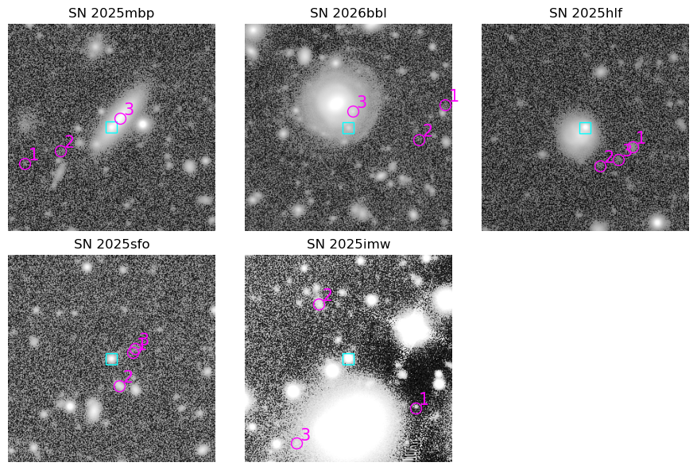

```python
fig, axes = plt.subplots(nrows=2, ncols=3, figsize=(9, 6))
axes = axes.flatten()
for i in range(len(targets)):
    subset = cutouts[i]
    wcs = subset.sky_projection
    subset_extent = (subset.bbox.x.start, subset.bbox.x.stop,
                     subset.bbox.y.start, subset.bbox.y.stop)
    img_array = subset.image.array
    zscale = ZScaleInterval(krej=1)
    vmin, vmax = zscale.get_limits(img_array)
    norm = mcolors.AsinhNorm(linear_width=1.0, vmin=vmin, vmax=vmax)
    axes[i].imshow(img_array, cmap='gray', norm=norm, extent=subset_extent, origin='lower')
    sn_coord = SkyCoord(targets['ra'][i], targets['dec'][i], unit="deg")
    sn_xy = wcs.sky_to_pixel(sn_coord)
    axes[i].plot(sn_xy.x, sn_xy.y, 's', ms=10, color='None', mec='cyan', mew=1)
    tx = np.where((objects['diaObjectId'] == targets['diaObjectId'][i])
                  & (objects['distance_arcsec'] > 0.5)
                  & ((objects['refExtendedness'] == 1)
                     | (objects['refSizeExtendedness'] >= 0.5)))[0]
    temp = objects[tx]
    temp.sort('ell_r')
    for x in range(3):
        coord = SkyCoord(temp['coord_ra'][x], temp['coord_dec'][x], unit="deg")
        xy = wcs.sky_to_pixel(coord)
        axes[i].plot(xy.x, xy.y, symbol, ms=10, color='None', mec='magenta', mew=1)
        axes[i].text(xy.x + 5, xy.y + 5, str(x+1), fontsize=15, color='magenta')
    axes[i].set_title(targets['sn_name'][i])
    axes[i].axis("off")
    del subset
axes[5].remove()
plt.tight_layout()
plt.show()
```

> **Figure 9:** Similar to Figures 5 through 8, but only the supernova's coordinates (cyan square) and the three nearest likely extended objects by effective elliptical radius, derived from the second moments, are marked with magenta circles.

Based on nearest objects by elliptical radius (second moments):

- SN 2025mbp - the third-nearest extended object is the confirmed host.
- SN 2026bbl - none of the nearest extended objects are the confirmed host.
- SN 2025hlf - none of the nearest extended objects are the confirmed host.
- SN 2025sfo - the situation is unclear.
- SN 2025imw - none of the nearest extended objects are the *potential* large elliptical host (but see Section 5).

## 5. Summary of challenges for low-z SN host association

This section reviews the main lessons learned about host association with DP2 objects and deep coadd images.

### 5.1. DP2 deep coadd images can contain transient light

As explored in Sections 3 and 4.1, the DP2 deep coadd images can include light from a transient, and thus the `Object` table can include a row for the transient itself, which complicates the cross-matching to identify candidate host galaxies.

One potential workaround is to consider pre-transient imaging from other surveys. For example, SN 2025sfo is the highest redshift supernova of the five used in this tutorial, and it is a type SLSN-I which are known to occur in faint, dwarf, star-forming galaxies. In pre-SN images from the [DECam Legacy Survey](https://www.legacysurvey.org/viewer?ra=320.073119&dec=-17.208876&mark=320.073119%2C-17.208876&zoom=16&layer=ls-dr10) and from [PanSTARRS](https://ps1images.stsci.edu/cgi-bin/ps1cutouts?filter=color&verbose=0&filetypes=stack&pos=320.073118512-17.2088758337&size=400), a very small source is visible at the supernova's location. For SN 2025sfo, the point-source in the DP2 deep coadd image could be the host galaxy, or the supernova light, or a mix of both.

Another potential workaround is to generate custom coadds of LSST visit images using only visits from before (or well after) the transient. Figure 4 shows that for SN 2025sfo, DP2 includes several pre-supernova visits. The creation of custom coadds is demonstrated in a different tutorial.

### 5.2. Extendedness estimates can be inaccurate

For example, the confirmed host galaxy for SN 2025hlf is a face-on spiral. However, in the DP2 `Object` table that object's extendedness parameters did not indicate that it was extended, and its $i$-band `cModel` fluxes (appropriate for extended objects) were not populated, only the PSF fluxes. This caused that object to be misinterpreted as a point-like source and not be considered as a potential host in Section 4.3, 4.4, or 4.5.

Retrieve additional values about the measurement of the confirmed host galaxy for SN 2025hlf.

> **Notice:** The following query can take a few minutes to execute.

```python
object_id = 794819432252726615
query = """SELECT objectId, coord_ra, coord_dec, refBand, refExtendedness, refSizeExtendedness,
        i_psfFlux, i_psfFluxErr, i_psfFlux_flag, i_cModelFlux, i_cModelFluxErr, i_cModel_flag,
        i_kronRad, i_kronFlux_flag, i_kronFlux_flag_bad_radius,
        i_ixx, i_ixy, i_iyy, i_blendedness_flag,
        detect_fromBlend, deblend_blendNChild, deblend_parentNChild
        FROM dp2.Object WHERE objectId = {}""".format(object_id)
job = tap_service.submit_job(query, uploads={"ut": targets})
job.run()
job.wait(phases=['COMPLETED', 'ERROR'])
print('Job phase is', job.phase)
if job.phase == 'ERROR':
    job.raise_if_error()
assert job.phase == 'COMPLETED'
objects_2025hlf = job.fetch_result().to_table()
```

```
Job phase is COMPLETED
```

A closer look at this galaxy's parameters in the `Object` table reveal flags related to the Kron measurement, as well as the deblending process. A deeper dive into *why* the deblending and measurement steps may not have worked correctly for this particular galaxy is beyond the scope of this tutorial. Look for other tutorials on interpreting the deblender outputs and rerunning source detection. The main takeaway point is that extendedness parameters can be inaccurate for extended low-redshift galaxies, and that should be kept in mind during host association analyses.

```python
objects_2025hlf
```

*Table length=1*

| objectId int64 | coord_ra deg float64 | coord_dec deg float64 | refBand str1 | refExtendedness float32 | refSizeExtendedness float32 | i_psfFlux nJy float32 | i_psfFluxErr nJy float32 | i_psfFlux_flag bool | i_cModelFlux nJy float32 | i_cModelFluxErr nJy float32 | i_cModel_flag bool | i_kronRad pix float32 | i_kronFlux_flag bool | i_kronFlux_flag_bad_radius bool | i_ixx pix2 float32 | i_ixy pix2 float32 | i_iyy pix2 float32 | i_blendedness_flag bool | detect_fromBlend bool | deblend_blendNChild int32 | deblend_parentNChild int32 |
| --- | --- | --- | --- | --- | --- | --- | --- | --- | --- | --- | --- | --- | --- | --- | --- | --- | --- | --- | --- | --- | --- |
| 794819432252726615 | 185.98898308220848 | 8.7625759100374 | i | -- | -- | 56680.2 | 59.5277 | True | -- | -- | True | 8.80335 | True | False | 97.5947 | -9.02303 | 86.3549 | True | True | 3 | 12 |

### 5.3. Potential hosts can have (very) large offsets

For this example, consider SN 2025imw.

```python
i = 4
targets[i]
```

*Row index=4*

| sn_name str10 | diaObjectId int64 | ra deg float64 | dec deg float64 | nDiaSources int64 |
| --- | --- | --- | --- | --- |
| SN 2025imw | 764124984615370762 | 310.17861663711346 | -20.435673493712155 | 72 |

Retrieve objects within 60 arcsec, instead of 30 arcsec as done in Section 4.

```python
rad_deg = 60.0/3600.0
sn_ra = targets['ra'][i]
sn_dec = targets['dec'][i]
query = """SELECT objectId, coord_ra, coord_dec, refBand, refExtendedness, refSizeExtendedness,
        i_psfFlux, i_psfFluxErr, i_psfFlux_flag, i_cModelFlux, i_cModelFluxErr, i_cModel_flag,
        i_kronRad, i_kronFlux_flag, i_kronFlux_flag_bad_radius, i_ixx, i_ixy, i_iyy,
        DISTANCE(POINT('ICRS', coord_ra, coord_dec), POINT('ICRS', {}, {}))*3600 AS distance_arcsec
        FROM dp2.Object
        WHERE CONTAINS(POINT('ICRS', coord_ra, coord_dec), CIRCLE('ICRS', {}, {}, {})) = 1
        AND (i_psfFlux/i_psfFluxErr > 5 OR i_cModelFlux/i_cModelFluxErr > 5)
        ORDER BY distance_arcsec
        """.format(sn_ra, sn_dec, sn_ra, sn_dec, rad_deg)
job = tap_service.submit_job(query)
job.run()
job.wait(phases=['COMPLETED', 'ERROR'])
print('Job phase is', job.phase)
if job.phase == 'ERROR':
    job.raise_if_error()
assert job.phase == 'COMPLETED'
objects_2025imw = job.fetch_result().to_table()
```

```
Job phase is COMPLETED
```

Create a larger cutout image for SN 2025imw, about 2 arcmin per side

```python
query = """band.name = :band AND patch.region OVERLAPS POINT(:ra, :dec)"""
binder = {"band": 'i', "ra": targets['ra'][i], "dec": targets['dec'][i]}
refs = butler.query_datasets("deep_coadd", where=query, bind=binder)
data_id = refs[0].dataId
wcs = butler.get("deep_coadd.sky_projection", dataId=data_id)
sn_coord = SkyCoord(targets['ra'][i], targets['dec'][i], unit="deg")
sn_xy = wcs.sky_to_pixel(sn_coord)
subset_size = 300
selection_bbox = Box.factory[round(sn_xy.y):round(sn_xy.y)+1,
                             round(sn_xy.x):round(sn_xy.x)+1].padded(subset_size)
params = {'bbox': selection_bbox}

subset = butler.get(refs[0], parameters=params)
wcs = subset.sky_projection
subset_extent = (subset.bbox.x.start, subset.bbox.x.stop,
                 subset.bbox.y.start, subset.bbox.y.stop)
img_array = subset.image.array
zscale = ZScaleInterval(krej=1)
vmin, vmax = zscale.get_limits(img_array)
norm = mcolors.AsinhNorm(linear_width=1.0, vmin=vmin, vmax=vmax)
sn_coord = SkyCoord(targets['ra'][i], targets['dec'][i], unit="deg")
sn_xy = wcs.sky_to_pixel(sn_coord)
```

Display the larger cutout, with markers for all galaxies within the 60 arcsec radius.

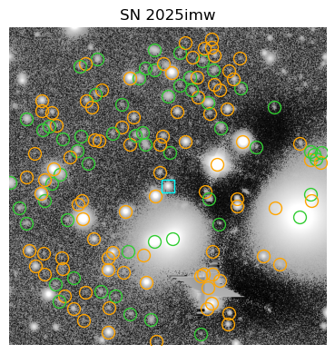

```python
fig, ax = plt.subplots(1, figsize=(4, 4))
ax.imshow(img_array, cmap='gray', norm=norm, extent=subset_extent, origin='lower')
ax.plot(sn_xy.x, sn_xy.y, 's', ms=10, color='None', mec='cyan', mew=1)
for x in range(len(objects_2025imw)):
    color = 'limegreen'
    symbol = 'o'
    if (objects_2025imw['refExtendedness'][x] == 0) or \
       (objects_2025imw['refSizeExtendedness'][x] < 0.5) or \
       (objects_2025imw['refExtendedness'].mask[x]):
        color = 'orange'
    if objects_2025imw['distance_arcsec'][x] >= 0.5:
        coord = SkyCoord(objects_2025imw['coord_ra'][x],
                         objects_2025imw['coord_dec'][x], unit="deg")
        xy = wcs.sky_to_pixel(coord)
        ax.plot(xy.x, xy.y, symbol, ms=10, color='None', mec=color, mew=1)
ax.axis("off")
ax.set_title(targets['sn_name'][i])
plt.tight_layout()
plt.show()
```

Calculate the effective Kron separation and the effective elliptical radius from the adaptive moments.

```python
objects_2025imw['distance_pix'] = objects_2025imw['distance_arcsec'] / 0.2
objects_2025imw['eff_kron_sep'] = objects_2025imw['distance_pix'] / objects_2025imw['i_kronRad']
```

```python
objects_2025imw['x'] = np.zeros(len(objects_2025imw), dtype='float')
objects_2025imw['y'] = np.zeros(len(objects_2025imw), dtype='float')
objects_2025imw['ell_r'] = np.zeros(len(objects_2025imw), dtype='float')
coords = SkyCoord(objects_2025imw['coord_ra'], objects_2025imw['coord_dec'], unit="deg")
xy = wcs.sky_to_pixel(coords)
objects_2025imw['x'] = xy.x
objects_2025imw['y'] = xy.y
sn_x = sn_xy.x
sn_y = sn_xy.y
xr = sn_x - objects_2025imw['x']
yr = sn_y - objects_2025imw['y']
Cxx = objects_2025imw['i_iyy'] / ((objects_2025imw['i_ixx'] * objects_2025imw['i_iyy'])
                                  - objects_2025imw['i_ixy'])
Cyy = objects_2025imw['i_ixx'] / ((objects_2025imw['i_ixx'] * objects_2025imw['i_iyy'])
                                  - objects_2025imw['i_ixy'])
Cxy = -2.0 * (objects_2025imw['i_ixy']) / ((objects_2025imw['i_ixx'] * objects_2025imw['i_iyy'])
                                           - objects_2025imw['i_ixy'])
objects_2025imw['ell_r'] = np.sqrt((Cxx * xr**2) + (Cyy * yr**2) + (Cxy * xr * yr))
```

Display the three nearest galaxies by each of the extended-object effective distance measures.

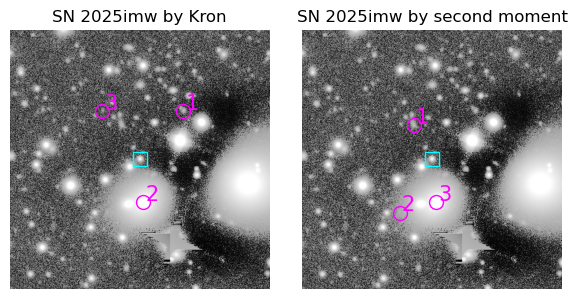

```python
fig, axes = plt.subplots(nrows=1, ncols=2, figsize=(6, 3))
axes = axes.flatten()
for j in range(2):
    axes[j].imshow(img_array, cmap='gray', norm=norm, extent=subset_extent, origin='lower')
    axes[j].plot(sn_xy.x, sn_xy.y, 's', ms=10, color='None', mec='cyan', mew=1)

j = 0
tx = np.where((objects_2025imw['distance_arcsec'] > 0.5)
              & (objects_2025imw['i_kronFlux_flag_bad_radius'] == 0)
              & ((objects_2025imw['refExtendedness'] == 1)
                 | (objects_2025imw['refSizeExtendedness'] >= 0.5)))[0]
temp = objects_2025imw[tx]
temp.sort('eff_kron_sep')
for x in range(3):
    coord = SkyCoord(temp['coord_ra'][x], temp['coord_dec'][x], unit="deg")
    xy = wcs.sky_to_pixel(coord)
    axes[j].plot(xy.x, xy.y, symbol, ms=10, color='None', mec='magenta', mew=1)
    axes[j].text(xy.x + 5, xy.y + 5, str(x+1), fontsize=15, color='magenta')
axes[j].set_title(targets['sn_name'][i] + ' by Kron')
axes[j].axis("off")
j = 1
tx = np.where((objects_2025imw['distance_arcsec'] > 0.5)
              & ((objects_2025imw['refExtendedness'] == 1)
                 | (objects_2025imw['refSizeExtendedness'] >= 0.5)))[0]
temp = objects_2025imw[tx]
temp.sort('ell_r')
for x in range(3):
    coord = SkyCoord(temp['coord_ra'][x], temp['coord_dec'][x], unit="deg")
    xy = wcs.sky_to_pixel(coord)
    axes[j].plot(xy.x, xy.y, symbol, ms=10, color='None', mec='magenta', mew=1)
    axes[j].text(xy.x + 5, xy.y + 5, str(x+1), fontsize=15, color='magenta')
axes[j].set_title(targets['sn_name'][i] + ' by second moment')
axes[j].axis("off")
plt.tight_layout()
plt.show()
```

> **Figure 11:** The $i$-band deep coadd cutout for SN 2025imw, with the top three nearest extended objects by effect Kron radius (left) and by adaptive moments (right). The bigger, brighter elliptical galaxy to the west is not marked, but consider this: some oversubtraction of the diffuse light in the region is exhibited by the darker regions around that larger galaxy, which could contribute to underestimated size measurements.

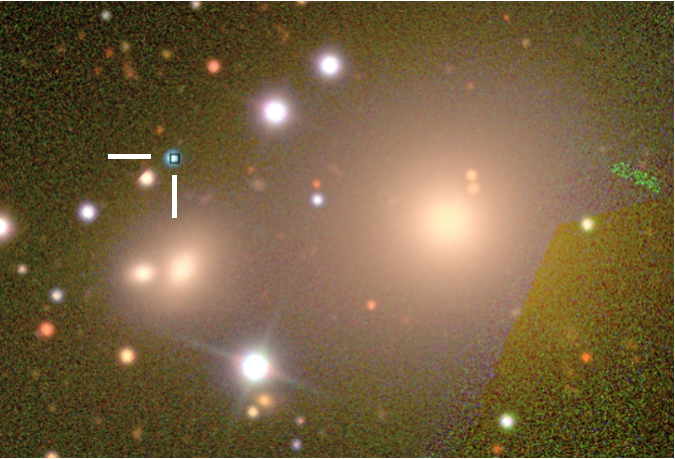

> **Figure 12:** A larger cutout of the "pretty"-background DP2 color image (the HiPS map) for the environment of SN 2025imw more clearly shows that extended light from the host galaxy permeates the region, including where SN 2025imw occurred.